The format of this lab follows the same format as the previous ones. Your goal is to predict the value of the third column (which will be missing on the test set) using the techniques we have learned so far.

# Set-up

Read in the following libraries and to load the metadata:

```r
library(readr)
library(dplyr)
```

```r
library(ggplot2)
library(viridis)
library(stringi)
library(keras)
stl <- read_csv("https://statsmaths.github.io/ml_data/stl_10.csv")
```

To get the embeddings, download this file as well:

```r
X <- as.matrix(read_csv("https://statsmaths.github.io/ml_data/stl_10_vgg16_cnn.csv"))
```

If you would like the raw image data as well, you can download that here (you do not need to use these, but are welcome to make use of the raw images for things such as finding negative examples):

- https://drive.google.com/open?id=0B6_9OUDRaPQsaHJhZzVvWW5IdWs

Once these are downloaded, you’ll have to run something like this:

```r
x96 <- read_rds("~/Desktop/stl_10_x96.rds")
```

If, for example, the file sits on your Desktop and you have a Mac. If you have trouble with any of this, please let me know as soon as possible.

# Lab 21

After loading in the data and the weights, we can begin by constructing the datasets required for our dense neural network.

```r
stl$class <- stl$class - 1
y <- stl$class

X_train <- X[stl$train_id == "train",]
y_train <- to_categorical(y[stl$train_id == "train"], num_classes = 10)
```

Next, we start with a basic neural network model with two hidden layers. It seems as though two hidden layer provided the best accuracy rates. I also decided to decrease the droupout rate since the model likely has alot of noise, it slightly improved my validation rate as well. I also decided to decrease my learning rate and increase the epochs to improve the range of convergence.

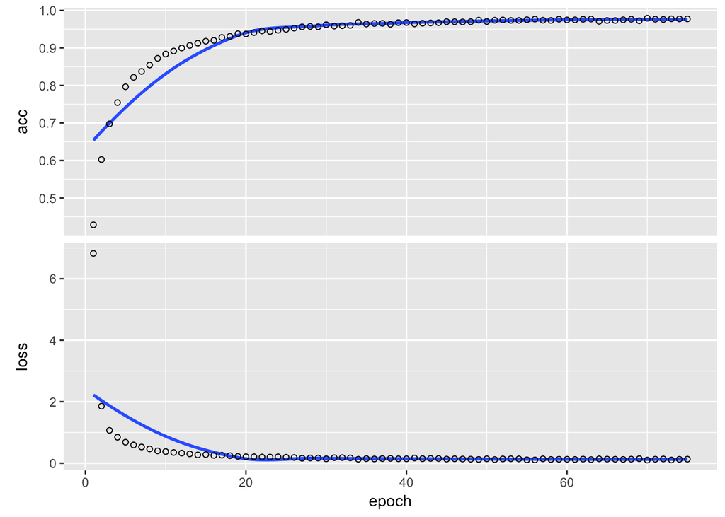

```r
model <- keras_model_sequential()
model %>%
  layer_dense(units = 64, input_shape = ncol(X_train)) %>%
  layer_activation(activation = "relu") %>%
  layer_dropout(rate = 0.12) %>%

  layer_dense(units = 64, input_shape = ncol(X_train)) %>%
  layer_activation(activation = "relu") %>%
  layer_dropout(rate = 0.12) %>%

  layer_dense(units = 10) %>%
  layer_activation(activation = "softmax")

model %>% compile(loss = 'categorical_crossentropy',
                  optimizer = optimizer_rmsprop(lr = 0.001),
                  metrics = c('accuracy'))

history <- model %>%
    fit(X_train, y_train, epochs = 75)
plot(history)
```

Taking a closer look at our validation rate, we see that, it does a pretty good job overall.

```r
y_pred <- predict_classes(model, X)

stl$class <- stl$class + 1
y_pred <- y_pred + 1

tapply(stl$class == y_pred, stl$train_id, mean)
```

```
##      test     train     valid
##        NA 0.9964615 0.8427692
```

```r
table(x = stl$class, y = y_pred)
```

```
##     y
## x      1   2   3   4   5   6   7   8   9  10
##   1  942   1   6   0   0   1   3   0  16   6
##   2   10 920   1  20   3   6   3   9   2   1
##   3    2   0 948   2   0   1   1   0   1  20
##   4    0   5   0 882  23  41   4  19   0   1
##   5    3   3   0  26 904  12  21   5   0   1
##   6    2   3   0  24   8 894  25  18   0   1
##   7    1   2   1   2  14  19 926   6   1   3
##   8    1   7   0  21   4   9   3 929   1   0
##   9    7   0   1   0   1   1   0   0 943  22
##   10   4   0  18   0   0   0   5   0  20 928
```

# Submission

The code below assumes that you have added a prediction named `class_pred` to every row of the dataset.

```r
stl$class_pred <- y_pred
submit <- select(stl, obs_id, class_pred)
write_csv(submit, "class21_submit.csv")
```

Now, upload this file (ends with “.Rmd”), the HTML output (ends with “.nb.html” or “.html”), and the csv file to GitHub.